# Assessing MLB Batter Ability using Statcast Data

Joe Catallini, Eric Bridgeford, Brian Gilbert, Jennifer Xu

## Introduction

- Baseball has long attracted statisticians as a sport
- Many aspects of baseball can be thought of as quasi-iid trials (pitches, plate appearances, defensive plays, etc.) with specific conditions (count, inning, score, etc.)
- Until recently, statistics used to assess the performance of batters have been outcome based (consider the following 7)
  - Strikeout*
  - Walk/Hit by pitch*
  - Field out
  - Single
  - Double
  - Triple
  - Homerun**

*completely determined by pitcher and batter

**almost completely determined by pitcher and batter (stadium effects and inside the park homeruns)

## Brief History of Batter Performance Statistics

- Batting Average (BA): Hits per at-bat
  - Ignores walks and hit by pitches
  - Treats every hit equally
- Slugging Percentage (SLG): Total bases per at-bats
  - Ignores walks and hit by pitches
  - Weights singles, doubles, triples, homeruns (1, 2, 3, 4)
- On-base Percentage (OBP): Total “reach-base-safely” per plate appearance
  - Incorporates walks and hit by pitches
  - Treats every “reach-base-safely” event equally
- OPS
  - OBP + SLG
- Weighted On-base Average (wOBA)
  - Incorporates walks and hit by pitches
  - Regression of historical data assigns linear weights based on expected run values of each event
  - Projects weights to approximate OBP distribution (for interpretability)
  - Weighted average of events per plate appearance

## Statcast

- Each of these new statistics may have been an improvement, however they all still rely on outcomes
- Batted ball outcomes (most notably field outs, singles, doubles, and triples) are influenced by factors outside the batter’s control (defensive positioning and proficiency, stadium effects, etc.)
- Beginning in 2015, a new technology called Statcast was introduced to the MLB which gathered data using high speed cameras to track the ball and players
- Baseball Savant has a processed version of the raw data available for public export
- The exportable data includes attributes of each batted ball, the associated pitch, and much, much more
- We have acquired this data from the 2017-2019 season (>500,000 events)

## Project goal

- The primary goal of the project is to utilize Statcast data to assess batter quality from the distribution of their batted balls
- To do this, we will apply methods to predict probabilities of each outcome based on batted ball attributes from the statcast data
  - Random forest
  - Kernel density estimator
  - Bayesian hierarchical models
- Primary predictors of interest
  - Launch speed: velocity of batted ball off the bat
  - Launch angle: angle of batted ball off the bat (relative to plane parallel to the ground)
  - Spray angle: angle of direction of the batted ball (with respect to the field)
  - Sprint speed: top sprint speed of the batter
- Other potential predictors of interest
  - Stadium
  - Defense and defensive alignment: team, infield and outfield shifts
  - Pitch attributes: velocity, spin, location, break, etc.
- We will express batter quality as an expectation of wOBA based on the Statcast data of their batted ball events
- Using this metric, we can evaluate if a given batter’s expected wOBA is a better predictor of their future performance than their actual wOBA

## DAG

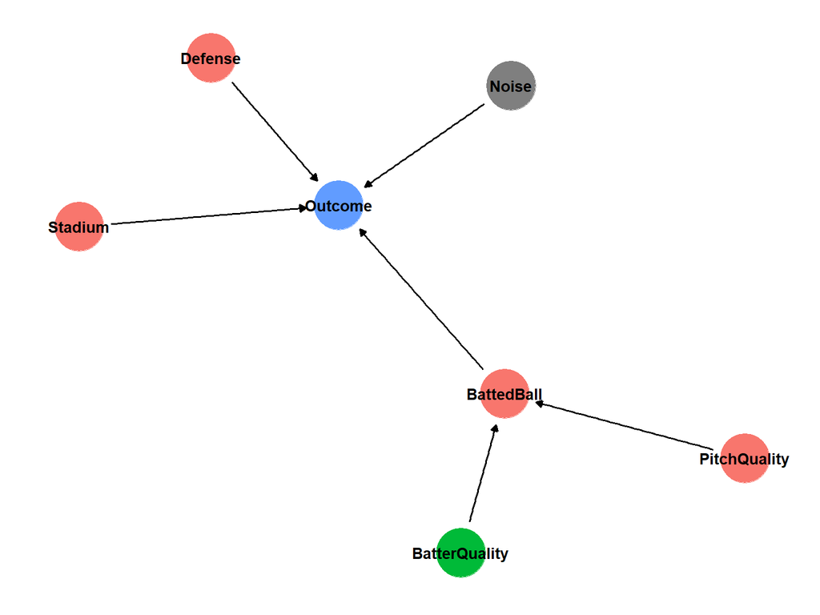

## Figure

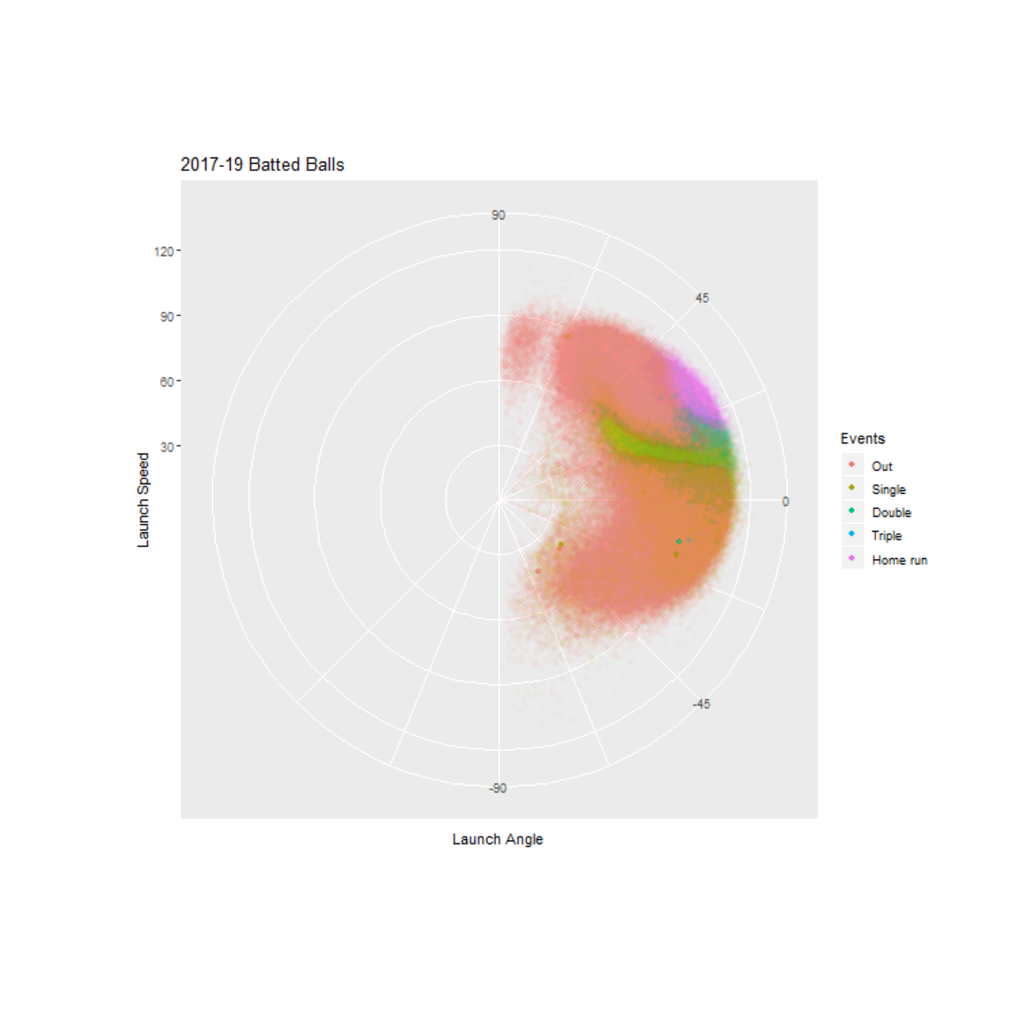